# Практика 5. Типы данных

осень 2026

Андрей Стоян, Илья Колегов

осень 2026

## Летучка 5

**Летучка 5** · 7 минут · Ваше ФИ: ____________________

1. Расставьте скобки в типе `String -> Int -> Bool`: _________________________
2. Напишите наиболее общий тип `\x -> (x, x)`: ______________
3. Сделайте один β-шаг: $\ (\lambda x.\,x\ a)\ b \rightsquigarrow$ ______
4. Дано `fac 0 = 1; fac n = n * fac (n - 1)`. Раскройте только вызов, арифметику не считайте: `fac 3` ⇝ __________________
5. Список `[10, 20, 30]` сопоставили с образцом `x : xs`. Чему равно `xs`? ____________

## Конструкторы и сопоставление

## Тип или конструктор?

Даны объявления. Напишите типы `CatD`, `Dog`, `Dog "barsik"` и `Parrot`.

```haskell
data CatT = CatD String Int
data Pet = Cat CatT | Dog String Int | Parrot
```

```haskell
ghci> :t CatD
CatD :: String -> Int -> CatT
ghci> :t Dog
Dog :: String -> Int -> Pet
ghci> :t Dog "barsik"
Dog "barsik" :: Int -> Pet
ghci> :t Parrot
Parrot :: Pet
```

- `CatT`, `Pet` — типы; `CatD`, `Cat`, `Dog`, `Parrot` — конструкторы данных
- Конструктор можно применить частично, как функцию

## Разобрать то, что сконструировали

```haskell
showPet :: Pet -> String
showPet pet = case pet of
  Parrot -> "Parrot"
  Dog name _ -> "Dog: " ++ name
  Cat (CatD name _) -> "Cat: " ++ name
```

Какую ветку выберет `showPet (Cat (CatD "murka" 2))`? Какие имена свяжет образец?

Последнюю: `name = "murka"`, возраст игнорируется. Результат — `"Cat: murka"`.

- Δ **Сопоставление с образцом** разбирает значение по конструктору
- Вложенный образец разбирает и внешнюю обёртку `Cat`, и внутреннюю `CatD`

## Возраст: что делать с попугаем?

Закончите функцию, чтобы она обрабатывала каждый вариант `Pet`. Возраст попугая в нашем типе не хранится.

```haskell
age :: Pet -> Maybe Int
age pet = case pet of
  Dog _ years -> Just years
  Cat (CatD _ years) -> Just years
  -- допишите недостающую ветку
```

```haskell
  Parrot -> Nothing
```

- Δ **Полнота сопоставления**: учтены все конструкторы
- `Nothing` — нет данных о возрасте; `Just 0` — известный возраст, равный нулю

## Рекурсивное дерево

## Функция следует за структурой типа

```haskell
data Tree a = Leaf a | Node (Tree a) a (Tree a)
```

**Два конструктора → две ветки**

```haskell
height :: Tree a -> Int
height t = case t of
  Leaf _ -> 1
  Node l _ r ->
    1 + max (height l) (height r)
```

**Два поддерева → два вызова**

Node x

l

r

## Предскажите высоту

Запишите раскрытие `height t` до числового результата. Высота листа — 1.

```haskell
data Tree a = Leaf a | Node (Tree a) a (Tree a)
t = Node (Leaf 1) 2 (Node (Leaf 3) 4 (Leaf 5))
height (Leaf _) = 1
height (Node l _ r) = 1 + max (height l) (height r)
```

## Высота: спуск и возврат

В `Node` два рекурсивных вызова. Сначала получим результат слева.

`1 + max (height l) (height r)`

вызовы и результаты

`Node 2`: ждём `l` и `r`

Node 2

Leaf 1

Node 4

Leaf 3

Leaf 5

## Высота: спуск и возврат

Спускаемся в левое поддерево: встретили `Leaf`.

`height (Leaf 1)`

вызовы и результаты

`Node 2`: ждём `l` и `r`

↓ `Leaf 1`: база

Node 2

Leaf 1

Node 4

Leaf 3

Leaf 5

## Высота: спуск и возврат

Возвращаем `1` родителю. Правый результат ещё неизвестен.

`1 + max 1 (height r)`

вызовы и результаты

`Node 2`: ждём `l` и `r`

↓ `Leaf 1`: база

↑ слева вернулась `1`

Node 2

Leaf 1

Node 4

Leaf 3

Leaf 5

1

## Высота: спуск и возврат

Спускаемся вправо. Здесь снова `Node` с двумя поддеревьями.

`1 + max (height rl) (height rr)`

вызовы и результаты

`Node 2`: ждём `l` и `r`

↓ `Leaf 1`: база

↑ слева вернулась `1`

↓ `Node 4`: ждём `rl`, `rr`

Node 2

Leaf 1

Node 4

Leaf 3

Leaf 5

1

## Высота: спуск и возврат

Левый ребёнок этого узла — лист. Его высота тоже `1`.

`height (Leaf 3)`

вызовы и результаты

`Node 2`: ждём `l` и `r`

↓ `Leaf 1`: база

↑ слева вернулась `1`

↓ `Node 4`: ждём `rl`, `rr`

↓ `Leaf 3`: база

Node 2

Leaf 1

Node 4

Leaf 3

Leaf 5

1

## Высота: спуск и возврат

Возвращаемся к `Node 4`: слева уже `1`, справа ещё вызов.

`1 + max 1 (height rr)`

вызовы и результаты

`Node 2`: ждём `l` и `r`

↓ `Leaf 1`: база

↑ слева вернулась `1`

↓ `Node 4`: ждём `rl`, `rr`

↓ `Leaf 3`: база

↑ от `Leaf 3` вернулась `1`

Node 2

Leaf 1

Node 4

Leaf 3

Leaf 5

1

1

## Высота: спуск и возврат

Спускаемся к последнему листу.

`height (Leaf 5)`

вызовы и результаты

`Node 2`: ждём `l` и `r`

↓ `Leaf 1`: база

↑ слева вернулась `1`

↓ `Node 4`: ждём `rl`, `rr`

↓ `Leaf 3`: база

↑ от `Leaf 3` вернулась `1`

↓ `Leaf 5`: база

Node 2

Leaf 1

Node 4

Leaf 3

Leaf 5

1

1

## Высота: спуск и возврат

Оба результата готовы: высота правого поддерева равна `2`.

`1 + max 1 1 = 2`

вызовы и результаты

`Node 2`: ждём `l` и `r`

↓ `Leaf 1`: база

↑ слева вернулась `1`

↓ `Node 4`: ждём `rl`, `rr`

↓ `Leaf 3`: база

↑ от `Leaf 3` вернулась `1`

↓ `Leaf 5`: база

↑ `Node 4`: результат `2`

Node 2

Leaf 1

Node 4

Leaf 3

Leaf 5

1

1

1

2

## Высота: спуск и возврат

Возвращаем `2` корню. Всё дерево имеет высоту `3`.

`1 + max 1 2 = 3`

вызовы и результаты

`Node 2`: ждём `l` и `r`

↓ `Leaf 1`: база

↑ слева вернулась `1`

↓ `Node 4`: ждём `rl`, `rr`

↓ `Leaf 3`: база

↑ от `Leaf 3` вернулась `1`

↓ `Leaf 5`: база

↑ `Node 4`: результат `2`

↑ корень: результат `3`

Node 2

Leaf 1

Node 4

Leaf 3

Leaf 5

1

1

1

2

3

## Теперь сумма: тот же каркас

Заполните три пропуска и найдите сумму значений того же дерева `t`.

```haskell
sumTree :: Tree Int -> Int
sumTree t = case t of
  Leaf x -> ___
  Node l x r -> ___ + x + ___
```

```haskell
sumTree t = case t of
  Leaf x -> x
  Node l x r -> sumTree l + x + sumTree r
```

Сумма — `15`.

## Сумма: тот же спуск, другие результаты

Та же структура вызовов. Теперь учитываем и значение в каждом узле.

`sumTree l + 2 + sumTree r`

вызовы и результаты

`Node 2`: ждём `l` и `r`

Node 2

Leaf 1

Node 4

Leaf 3

Leaf 5

## Сумма: тот же спуск, другие результаты

Спускаемся влево. Лист возвращает своё значение.

`sumTree (Leaf 1)`

вызовы и результаты

`Node 2`: ждём `l` и `r`

↓ `Leaf 1`: возвращает `1`

Node 2

Leaf 1

Node 4

Leaf 3

Leaf 5

## Сумма: тот же спуск, другие результаты

Левый результат вернулся. Корню ещё нужна сумма справа.

`1 + 2 + sumTree r`

вызовы и результаты

`Node 2`: ждём `l` и `r`

↓ `Leaf 1`: возвращает `1`

↑ слева вернулась `1`

Node 2

Leaf 1

Node 4

Leaf 3

Leaf 5

1

## Сумма: тот же спуск, другие результаты

В правом поддереве снова тот же каркас.

`sumTree rl + 4 + sumTree rr`

вызовы и результаты

`Node 2`: ждём `l` и `r`

↓ `Leaf 1`: возвращает `1`

↑ слева вернулась `1`

↓ `Node 4`: ждём `rl`, `rr`

Node 2

Leaf 1

Node 4

Leaf 3

Leaf 5

1

## Сумма: тот же спуск, другие результаты

Левый лист возвращает `3`.

`sumTree (Leaf 3)`

вызовы и результаты

`Node 2`: ждём `l` и `r`

↓ `Leaf 1`: возвращает `1`

↑ слева вернулась `1`

↓ `Node 4`: ждём `rl`, `rr`

↓ `Leaf 3`: возвращает `3`

Node 2

Leaf 1

Node 4

Leaf 3

Leaf 5

1

## Сумма: тот же спуск, другие результаты

Возвращаемся к родителю: остался один рекурсивный вызов.

`3 + 4 + sumTree rr`

вызовы и результаты

`Node 2`: ждём `l` и `r`

↓ `Leaf 1`: возвращает `1`

↑ слева вернулась `1`

↓ `Node 4`: ждём `rl`, `rr`

↓ `Leaf 3`: возвращает `3`

↑ от `Leaf 3` вернулась `3`

Node 2

Leaf 1

Node 4

Leaf 3

Leaf 5

1

3

## Сумма: тот же спуск, другие результаты

Последний лист возвращает `5`.

`sumTree (Leaf 5)`

вызовы и результаты

`Node 2`: ждём `l` и `r`

↓ `Leaf 1`: возвращает `1`

↑ слева вернулась `1`

↓ `Node 4`: ждём `rl`, `rr`

↓ `Leaf 3`: возвращает `3`

↑ от `Leaf 3` вернулась `3`

↓ `Leaf 5`: возвращает `5`

Node 2

Leaf 1

Node 4

Leaf 3

Leaf 5

1

3

## Сумма: тот же спуск, другие результаты

У правого узла готовы все компоненты суммы: `3 + 4 + 5 = 12`.

`3 + 4 + 5 = 12`

вызовы и результаты

`Node 2`: ждём `l` и `r`

↓ `Leaf 1`: возвращает `1`

↑ слева вернулась `1`

↓ `Node 4`: ждём `rl`, `rr`

↓ `Leaf 3`: возвращает `3`

↑ от `Leaf 3` вернулась `3`

↓ `Leaf 5`: возвращает `5`

↑ `Node 4`: результат `12`

Node 2

Leaf 1

Node 4

Leaf 3

Leaf 5

1

3

5

12

## Сумма: тот же спуск, другие результаты

Возвращаем `12` корню: итоговая сумма равна `15`.

`1 + 2 + 12 = 15`

вызовы и результаты

`Node 2`: ждём `l` и `r`

↓ `Leaf 1`: возвращает `1`

↑ слева вернулась `1`

↓ `Node 4`: ждём `rl`, `rr`

↓ `Leaf 3`: возвращает `3`

↑ от `Leaf 3` вернулась `3`

↓ `Leaf 5`: возвращает `5`

↑ `Node 4`: результат `12`

↑ корень: результат `15`

Node 2

Leaf 1

Node 4

Leaf 3

Leaf 5

1

3

5

12

15

## Полиморфизм и кайнды

## Меняем значения, сохраняем дерево

Заполните пропуски. Функция `f` может менять тип содержимого, а форма дерева должна сохраниться.

```haskell
transform :: (a -> b) -> Tree a -> Tree b
transform f t = case t of
  Leaf x -> Leaf ___
  Node l x r -> Node ___ ___ ___
```

```haskell
transform f t = case t of
  Leaf x -> Leaf (f x)
  Node l x r -> Node (transform f l) (f x) (transform f r)
```

- Схема рекурсии прежняя; результаты теперь собираются обратно в дерево
- Высота не меняется: `height (transform f t) == height t`

## Терм → тип → кайнд

Начинаем с терма: `Just True` — выражение, которое можно вычислить.

Just True

терм

## Терм → тип → кайнд

Тип терма описывает результат: `Just True :: Maybe Bool`.

Just True

Maybe Bool

терм

тип

## Терм → тип → кайнд

У типа тоже есть характеристика: `Maybe Bool :: *`. Её называют **кайндом**.

Just True

Maybe Bool

терм

тип

кайнд

## Кайнд: что принимает конструктор типа

`Maybe :: * -> *`: принимает обычный тип и даёт обычный тип.

`Maybe Bool`

Maybe

Bool

вход

выход

:: *

## Кайнд: что принимает конструктор типа

Тип `Bool` занимает входной слот: кайнды совпали.

`Maybe Bool`

Maybe

Bool

вход

выход

Bool :: *

## Кайнд: что принимает конструктор типа

Получаем `Maybe Bool :: *`. Стрелка в кайнде использована применением.

`Maybe Bool :: *`

Maybe

Maybe Bool

вход

выход

Maybe Bool :: *

## Кайнд: что принимает конструктор типа

А `Maybe Maybe` не подходит: аргумент имеет кайнд `* -> *`, вход требует `*`.

`Maybe Maybe`

Maybe

Maybe

вход

выход

:: * → *

## Предскажите кайнд

Определите кайнды `Tree`, `Tree Bool`, `Either String` и `Either String Int`. Затем проверим через `:k`.

```haskell
ghci> :kind Tree
Tree :: * -> *
ghci> :kind Tree Bool
Tree Bool :: *
ghci> :kind Either String
Either String :: * -> *
ghci> :kind Either String Int
Either String Int :: *
```

- `:t` спрашивает тип **терма**; `:k` спрашивает кайнд **типа**
- `Node` — конструктор данных; `Tree` — конструктор типа

## Списки

## Список: две ветки, одно поддерево

```haskell
-- Схематически: встроенный список устроен так
-- data List a = Nil | Cons a (List a)
[]       -- пустой список
x : xs   -- голова и хвост
```

Напишите безопасную функцию взятия головы списка: на пустом списке возвращайте `Nothing`.

```haskell
safeHead :: [a] -> Maybe a
safeHead xs = case xs of
  [] -> ___
  x : _ -> ___
```

```haskell
  [] -> Nothing
  x : _ -> Just x
```

## Разворот: где скрыта лишняя работа?

```haskell
reverseSlow [] = []
reverseSlow (x : xs) = reverseSlow xs ++ [x]
```

Что делает `(++)` при каждом возврате? Какая сложность у разворота списка длины n?

Обходит левый список: суммарно `0 + 1 + … + (n - 1)` операций, то есть $O(n^2)$.

## Аккумулятор из П4 возвращается

```haskell
reverseFast xs = go [] xs
  where
    go acc [] = acc
    go acc (x : rest) = go (x : acc) rest
```

```
go [] [1,2,3]
⇝ go [1] [2,3]
⇝ go [2,1] [3]
⇝ go [3,2,1] []
⇝ [3,2,1]
```

- Добавление в начало — $O(1)$; весь разворот — $O(n)$

## Проектирование данных

## Запись: имена полей и обновление

```haskell
data CatRecord = CatRecord { catName :: String, catAge :: Int }
birthday cat = cat { catAge = catAge cat + 1 }
```

Для `cat = CatRecord "murka" 2` чему равны `catAge (birthday cat)` и `catAge cat`?

`3` и `2`: обновление возвращает новую запись.

- Селектор поля — функция: `catAge :: CatRecord -> Int`
- NB Если поле есть не у всех конструкторов, селектор может быть частичным

## `type` или `newtype`?

**Синонимы**

```haskell
type ModuleId = Int
type CourseId = Int
```

Оба имени обозначают тот же тип `Int`.

**Новые типы**

```haskell
newtype ModuleId = ModuleId Int
newtype CourseId = CourseId Int
```

Компилятор различает идентификаторы.

Нужно запретить перестановку аргументов `publish :: ModuleId -> CourseId -> String`. Какой вариант подходит?

`newtype`: ошибку представления можно поймать по типам до запуска.

## Персистентность: старый список остаётся

```haskell
ys = 1 : xs
zs = 2 : ys
```

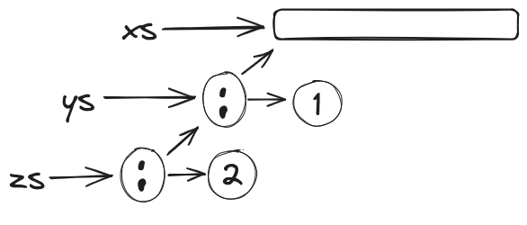

- `xs`, `ys`, `zs` используют общий хвост
- Чтобы добавить голову, достаточно новой ячейки; хвост копировать не нужно

## Полнота и структурная рекурсия

| Проверяем | Пример из пары |
| --- | --- |
| Учтены все конструкторы | `Parrot` получил ветку `Nothing` |
| Есть база рекурсии | `height (Leaf _) = 1` |
| Вызов идёт на меньшую структуру | `height l`, `height r` |
| Результат выражает отсутствие данных | `Maybe Int`, `Maybe a` |

Для конечного дерева такая рекурсия завершается. Полнота сопоставления сама по себе завершение не гарантирует.

## Что вы теперь умеете

- Читать типы конструкторов и частично применять их
- Строить сопоставление по вариантам типа
- Писать рекурсию по дереву и списку
- Различать терм, тип и кайнд
- Выбирать `Maybe`, `type` и `newtype` по смыслу задачи

## Домашка: перенос техники

- Сначала выпишите конструкторы и варианты входа
- Затем базовые случаи и рекурсивные вызовы
- Проверьте пустые структуры и отсутствие данных
- Сверяйтесь с сигнатурой и запускайте `make check`

На следующей паре — общие интерфейсы разных типов: классы типов.

## Материалы

## Если тип применили неправильно

```
ghci> :kind Maybe Maybe
<interactive>:1:7: error: [GHC-83865]
    • Expecting one more argument to ‘Maybe’
      Expected a type, but ‘Maybe’ has kind ‘* -> *’
    • In the first argument of ‘Maybe’, namely ‘Maybe’
      In the type ‘Maybe Maybe’
```

`Maybe` ждёт обычный тип, а ему передали конструктор типа.

## Питомцы: ещё одно упражнение

Добавьте префикс `"baron "` к имени питомца.

```haskell
baronify :: Pet -> Pet
baronify pet = case pet of
  Parrot -> Parrot
  Dog name years -> Dog ("baron " ++ name) years
  Cat (CatD name years) -> Cat (CatD ("baron " ++ name) years)
```

## Дуплицирование элементов списка

Дуплицируйте элементы с чётными номерами, начиная с нуля.

```haskell
dupEvens :: [a] -> [a]
dupEvens = concat . map f . zip [0..]
  where
    f (i, x) = if odd i then [x] else [x, x]
```

## Кайнды: дополнительные примеры

```haskell
data Free f a = Pure a | Free (f (Free f a))
-- Free :: (* -> *) -> * -> *

data HFree f a = HPure a | HFree (f (HFree f) a)
-- HFree :: ((* -> *) -> * -> *) -> * -> *
```

## Полиморфные типы и система $\lambda\omega$

```haskell
type Pair a b = forall c. (a -> b -> c) -> c
```

`Pair Int Char` $\equiv$ `forall c. (Int -> Char -> c) -> c`

$$\begin{aligned}
&\mathbf{Pair} : * \to * \to * \\
&\mathbf{Pair} = \lambda \alpha^*\,\beta^*.\,\forall \gamma.\,(\alpha\to\beta\to\gamma)\to\gamma \\
&\mathbf{pair} : \forall \alpha\,\beta.\,\alpha\to\beta\to\mathbf{Pair}\ \alpha\ \beta \\
&\mathbf{pair} = \Lambda \alpha^*\,\beta^*.\,\lambda x^\alpha\,y^\beta.\,(\Lambda \gamma^*.\,\lambda f^{\alpha\to\beta\to\gamma}.\,f\ x\ y) \\
&\mathbf{fst} : \forall \alpha\,\beta.\,\mathbf{Pair}\ \alpha\ \beta\to\alpha \\
&\mathbf{fst} = \Lambda \alpha^*\,\beta^*.\,\lambda p^{\mathbf{Pair}\ \alpha\ \beta}.\,p\ \alpha\ (\mathbf{K}\ \alpha\ \beta)
\end{aligned}$$

## Records и `coerce`: подробности

- Селекторы полей могут быть частичными у типов-сумм
- Для полей используют префиксы; дополнительные варианты синтаксиса дают расширения GHC
- `newtype` позволяет разделить типы без дополнительной обёртки во время исполнения

```haskell
import Data.Coerce (coerce)
intsToIds :: [Int] -> [CourseId]
intsToIds = coerce
```

[Расширения records](https://ghc.gitlab.haskell.org/ghc/doc/users_guide/exts/records.html) · [Parse, don’t validate](https://lexi-lambda.github.io/blog/2019/11/05/parse-don-t-validate/)

## Типы-произведения в C++

```cpp
#include <string>
struct CatT {
    std::string name;
    int age;
};
CatT createBarsik() { return CatT{"barsik", 4}; }
std::string getName(const CatT& cat) { return cat.name; }
```

Поля — компоненты произведения; конструктор создаёт значение, доступ к полю извлекает компонент.

## Типы-суммы в C

```c
struct Pet {
    enum { CAT, DOG, PARROT } tag;
    union {
        struct { const char *name; int age; } cat;
        struct { const char *name; int age; } dog;
    } value;
};
/* tag и value должны согласовываться */
switch (pet.tag) {
case CAT:    printf("Cat: %s", pet.value.cat.name); break;
case DOG:    printf("Dog: %s", pet.value.dog.name); break;
case PARROT: printf("Parrot"); break;
}
```

## Типы-суммы в C++

```cpp
std::variant<Cat, Dog, Parrot> pet{Cat{"barsik", 4}};
if (std::holds_alternative<Cat>(pet)) {
    std::cout << "Cat " << std::get<Cat>(pet).name;
} else if (std::holds_alternative<Dog>(pet)) {
    std::cout << "Dog " << std::get<Dog>(pet).name;
} else if (std::holds_alternative<Parrot>(pet)) {
    std::cout << "Parrot";
}
```

[std::variant](https://en.cppreference.com/w/cpp/utility/variant)

## Типы-суммы в Python

```python
class Pet: pass
class Cat(Pet):
    def __init__(self, name): self.name = name
class Dog(Pet):
    def __init__(self, name): self.name = name
class Parrot(Pet): pass

if isinstance(pet, Cat):
    print("Cat " + pet.name)
elif isinstance(pet, Dog):
    print("Dog " + pet.name)
elif isinstance(pet, Parrot):
    print("Parrot")
else:
    raise AssertionError("unreachable code")  # No exhaustiveness check
```

## Типы-суммы в Kotlin

```kotlin
sealed class Pet
class Cat(val name: String) : Pet()
class Dog(val name: String) : Pet()
class Parrot : Pet()

fun showPet(pet: Pet): String = when (pet) {
    is Cat -> "Cat: " + pet.name
    is Dog -> "Dog: " + pet.name
    is Parrot -> "Parrot"
}
```

Иерархия `sealed` позволяет компилятору проверять полноту выражения `when`.

## Что посмотреть в транспорте

- [Parse, don’t validate](https://lexi-lambda.github.io/blog/2019/11/05/parse-don-t-validate/)
- [(youtube) Тагир Валеев — Pattern matching в Java и его воображаемые друзья](https://youtu.be/qurG_J81_Cs?si=tINacE3c6ZF3CkvF)
- [The algebra (and calculus!) of algebraic data types](https://codewords.recurse.com/issues/three/algebra-and-calculus-of-algebraic-data-types)